# R Notebook sandbox: Playing with Exploratory Factor Analysis (EFA)

# 1 Top of the world

# 2 Exploratory Data Analysis (EDA)

Exploration is about discovery and looking for insights and themes. One data aggregation approach is based on some “linear model” assumptions, but begins in the exploratory phase. This is Exploratory Factor Analysis (EFA).

# 3 Exploratory Factor Analysis (EFA)

Generally, EFA intends to aggregate features of the data. This is common in the social sciences (psychology) where you ask a participant a lot of questions and you want to see if a group of these questions have similar responses.

For this introduction we will use the `personality-raw` data which is part of the latest version [0.1.4] of `library(humanVerseWSU);`

```r
packageVersion("humanVerseWSU");  # ‘0.1.4’  [SHOULD BE THIS]
```

```
## [1] '0.1.4'
```

```r
library(humanVerseWSU);
# You need R tools for this to work:  https://cran.r-project.org/bin/windows/Rtools/
# You may want to see if you have the latest version...
# library(devtools);
# detach(package:humanVerseWSU);
# install_github("MonteShaffer/humanVerseWSU/humanVerseWSU");
# Choose (3) None to minimize headaches ....
# library(humanVerseWSU);


## this code was in correlation notebook, repeating here ...


personality.raw = readRDS( system.file("extdata", "personality-raw.rds", package="humanVerseWSU") );

cleanupPersonalityDataFrame = function(df)
  {
  df = removeColumnsFromDataFrame(personality.raw, "V00");
  dim(df);  # 838


  ywd.cols = c("year","week","day");
  ywd = convertDateStringToFormat( df$date_test,
                                    c("%Y","%W","%j"),
                                    ywd.cols,
                                    "%m/%d/%Y %H:%M"
                                  );

  ndf = replaceDateStringWithDateColumns(df,"date_test",ywd);
  ndf = sortDataFrameByNumericColumns(ndf, ywd.cols, "DESC");
  ndf = removeDuplicatesFromDataFrame(ndf, "md5_email");

  dim(ndf); # 678
  ndf;
  }


personality.clean = cleanupPersonalityDataFrame(personality.raw);

### let's examine the data in total

personality.Vs = removeColumnsFromDataFrame(personality.clean,c("md5_email","year","week","day"));


X = personality.Vs;

Xs = scale(X);  # this is a good habit to get into, even if the data units are similar (as is the case here).

# because there are subject-level biases (e.g., a tendency for a user to answer questions higher/lower, maybe a "within-subject" scaling [row-level] followed by "within-item" scaling [col-level] may be appropriate.  Or maybe it removes some of the findings and their meaning?)

Xs = as.data.frame(Xs);

Xs;
```

|  | V01 | V02 | V03 | V04 | V05 | V06 | V07 | V08 | V09 | V10 | V11 | V12 | V13 | V14 | V15 | V16 | V17 | V18 | V19 | V20 | V21 | V22 | V23 | V24 | V25 | V26 | V27 | V28 | V29 | … |
| --- | --- | --- | --- | --- | --- | --- | --- | --- | --- | --- | --- | --- | --- | --- | --- | --- | --- | --- | --- | --- | --- | --- | --- | --- | --- | --- | --- | --- | --- | --- |
| 838 | -0.01739861 | 0.5746538 | 0.1411983 | 0.1824149 | -2.06363251 | -1.2854250 | 0.3540281 | -0.5788186 | -1.3153306 | 0.3987748 | 1.1343361 | 0.1174217 | -0.2938968 | 0.3630716 | 1.3352229 | -0.9007352 | 0.9660239 | -0.8674646 | -1.9188648 | 0.2617464 | -0.3818909 | -1.3682493 | 0.03404371 | -0.4470404 | 2.2643248 | -1.80808546 | 0.6648542 | -0.1556791 | -0.3348758 | … |
| 837 | -0.01739861 | -0.1660597 | 0.8719806 | 0.1824149 | 0.03246164 | 0.4019286 | 1.2463369 | 0.2404695 | -0.1690656 | -0.5208487 | -0.3796007 | 0.1174217 | -0.2938968 | 0.3630716 | 0.3649323 | 0.1540117 | -0.1403346 | 0.1625547 | -0.0992979 | 0.2617464 | 0.3313929 | 0.3887072 | 0.03404371 | 0.4686496 | 0.1564819 | 0.07354454 | 0.6648542 | -0.1556791 | -0.3348758 | … |
| 835 | 0.76901875 | 1.3153673 | -0.5895839 | 0.1824149 | 0.03246164 | 1.2456055 | -0.5382807 | 0.2404695 | -0.1690656 | -0.5208487 | -0.3796007 | -0.7118693 | 0.5724599 | 1.1347410 | -0.6053583 | 0.1540117 | 0.9660239 | 0.1625547 | -1.0090814 | 0.2617464 | -1.0951746 | -0.4897710 | 1.03759297 | -0.4470404 | -0.5461323 | 0.07354454 | -0.2664911 | 1.4315451 | -1.0817370 | … |
| 836 | -1.59023335 | -0.9067731 | 0.8719806 | 0.1824149 | 1.08050871 | -0.4417482 | -1.4305895 | -0.5788186 | 0.9771993 | -0.5208487 | -0.3796007 | 0.9467128 | -1.1602535 | -0.4085978 | 0.3649323 | -0.9007352 | -0.1403346 | 0.1625547 | -0.0992979 | -0.5675248 | -0.3818909 | -0.4897710 | 0.03404371 | 1.3843395 | -0.5461323 | -0.86727046 | -1.1978365 | -0.1556791 | -0.3348758 | … |
| 834 | 0.76901875 | -0.9067731 | 1.6027629 | 1.1123195 | 1.08050871 | 1.2456055 | 0.3540281 | -2.2173950 | 0.9771993 | 0.3987748 | 0.3773677 | 0.1174217 | -1.1602535 | -0.4085978 | 1.3352229 | 0.1540117 | 0.9660239 | -0.8674646 | -1.0090814 | -0.5675248 | 1.0446767 | 0.3887072 | 1.03759297 | 1.3843395 | -1.2487466 | 1.01435953 | -1.1978365 | -0.1556791 | -1.8285981 | … |
| 833 | 1.55543612 | -1.6474866 | 0.1411983 | 1.1123195 | 1.08050871 | 1.2456055 | 1.2463369 | 1.8790459 | 0.9771993 | 0.3987748 | -1.1365691 | 1.7760038 | 1.4388166 | 1.1347410 | 1.3352229 | 1.2087586 | 0.9660239 | 1.1925739 | 0.8104856 | -1.3967960 | -1.8084584 | 1.2671854 | 0.03404371 | 1.3843395 | -1.2487466 | 1.01435953 | 1.5961996 | 1.4315451 | -0.3348758 | … |
| 832 | -0.01739861 | -0.9067731 | 0.1411983 | -1.6773943 | 1.08050871 | -1.2854250 | -1.4305895 | -1.3981068 | 0.9771993 | -1.4404722 | -1.1365691 | -0.7118693 | -1.1602535 | -1.1802672 | -0.6053583 | -1.9554821 | 0.9660239 | 0.1625547 | -1.9188648 | -0.5675248 | -1.0951746 | -0.4897710 | 1.03759297 | -0.4470404 | -0.5461323 | 0.07354454 | -0.2664911 | -0.1556791 | -1.0817370 | … |
| 828 | -0.80381598 | 0.5746538 | -1.3203662 | 0.1824149 | 0.03246164 | -1.2854250 | -0.5382807 | -1.3981068 | -0.1690656 | 0.3987748 | -1.1365691 | -0.7118693 | -0.2938968 | 1.1347410 | 0.3649323 | 0.1540117 | 0.9660239 | 0.1625547 | -0.0992979 | -0.5675248 | -1.8084584 | -0.4897710 | 0.03404371 | -0.4470404 | -0.5461323 | 0.07354454 | 1.5961996 | -0.1556791 | -1.0817370 | … |
| 829 | 1.55543612 | 1.3153673 | -0.5895839 | 1.1123195 | 1.08050871 | 0.4019286 | -3.2152071 | 1.8790459 | 0.9771993 | 1.3183983 | -1.8935374 | 1.7760038 | 1.4388166 | 1.1347410 | 1.3352229 | 1.2087586 | 0.9660239 | -0.8674646 | -0.0992979 | 1.0910175 | 1.0446767 | 1.2671854 | 1.03759297 | -0.4470404 | -0.5461323 | 1.01435953 | 1.5961996 | 0.6379330 | 0.4119854 | … |
| 830 | -0.01739861 | -0.1660597 | 0.1411983 | -1.6773943 | 1.08050871 | -0.4417482 | -0.5382807 | 0.2404695 | 0.9771993 | -1.4404722 | -1.1365691 | 0.1174217 | -1.1602535 | -1.1802672 | 0.3649323 | 0.1540117 | -0.1403346 | 0.1625547 | -1.0090814 | 0.2617464 | -1.8084584 | -0.4897710 | 0.03404371 | 1.3843395 | -0.5461323 | 0.07354454 | -1.1978365 | 0.6379330 | -1.0817370 | … |

[output cut: 668 more lines]

## 3.1 Check Conditions of Multivariate Reduction

Remember, during “exploration” there are really not any significant constraints. In the previous notebook, I showed a few “normality” overlays of the PCA graphs for the countries (the elliptical forms).

Some call these “diagnostic tests”

### 3.1.1 KMO test

“The **Kaiser-Meyer-Olkin Measure of Sampling Adequacy** is a statistic that indicates the proportion of variance in your variables that might be caused by underlying factors. High values (close to 1.0) generally indicate that a factor analysis may be useful with your data. If the value is less than 0.50, the results of the factor analysis probably won’t be very useful.”

https://www.ibm.com/support/knowledgecenter/SSLVMB_23.0.0/spss/tutorials/fac_telco_kmo_01.html

```r
# this is the standard correlation matrix
Xs.corr = cor(Xs);

# library(KMO); # install.packages("KMO", dependencies=TRUE);  # not available for R == 4.0.2

library(REdaS); # install.packages("REdaS", dependencies=TRUE);

# https://www.rdocumentation.org/packages/REdaS/versions/0.9.3/topics/Kaiser-Meyer-Olkin-Statistics

Xs.KMO = KMOS(Xs);

str(Xs.KMO);
```

```
## List of 7
##  $ call   : language KMOS(x = Xs)
##  $ cormat : num [1:60, 1:60] 1 0.3533 -0.1868 0.0734 0.2002 ...
##   ..- attr(*, "dimnames")=List of 2
##   .. ..$ : chr [1:60] "V01" "V02" "V03" "V04" ...
##   .. ..$ : chr [1:60] "V01" "V02" "V03" "V04" ...
##  $ pcormat: num [1:60, 1:60] 1.7222 0.0544 0.0738 -0.0578 0.0135 ...
##   ..- attr(*, "dimnames")=List of 2
##   .. ..$ : chr [1:60] "V01" "V02" "V03" "V04" ...
##   .. ..$ : chr [1:60] "V01" "V02" "V03" "V04" ...
##  $ n      : int 678
##  $ k      : int 60
##  $ MSA    : Named num [1:60] 0.923 0.92 0.824 0.93 0.947 ...
##   ..- attr(*, "names")= chr [1:60] "V01" "V02" "V03" "V04" ...
##  $ KMO    : num 0.941
##  - attr(*, "class")= chr "MSA_KMO"
```

```r
my.kmo = Xs.KMO$KMO;
my.kmo;
```

```
## [1] 0.9408998
```

```r
if(my.kmo >= 0.90)
  {
  print("marvelous!");
  } else if(my.kmo >= 0.80)
    {
    print("meritorious!");
    }  else if(my.kmo >= 0.70)
        {
        print("middling!");
        } else if(my.kmo >= 0.60)
            {
            print("mediocre!");
            }  else if(my.kmo >= 0.50)
                {
                print("miserable!");
                } else {
                        print("mayhem!");
                        print("Oh snap!");
print("Kaiser-Meyer-Olkin (KMO) Test is a measure of how suited your data is for Factor Analysis. The test measures sampling adequacy for each variable in the model and for the complete model. The statistic is a measure of the proportion of variance among variables that might be common variance. The lower the proportion, the more suited your data is to Factor Analysis. <https://www.statisticshowto.com/kaiser-meyer-olkin/>");
                        }
```

```
## [1] "marvelous!"
```

### 3.1.2 Sphericity test

“**Bartlett’s test of sphericity** tests the hypothesis that your correlation matrix is an identity matrix, which would indicate that your variables are unrelated and therefore unsuitable for structure detection. Small values (less than 0.05) of the significance level indicate that a factor analysis may be useful with your data.”

https://www.ibm.com/support/knowledgecenter/SSLVMB_23.0.0/spss/tutorials/fac_telco_kmo_01.html

```r
# https://www.statology.org/bartletts-test-of-sphericity/
# Bartlett’s Test of Sphericity is not the same as Bartlett’s Test for Equality of Variances.

# this is the standard correlation matrix
Xs.corr = cor(Xs);

library(psych); # install.packages("psych", dependencies=TRUE);

Xs.bartlett = cortest.bartlett(Xs.corr, n = nrow(Xs));

str(Xs.bartlett);
```

```
## List of 3
##  $ chisq  : num 18349
##  $ p.value: num 0
##  $ df     : num 1770
```

```r
# alpha level
alpha = 0.05;

if(Xs.bartlett$p.value < alpha)
  {
  print(paste0("Bartlett's test of sphericity ... pvalue < alpha ... ", Xs.bartlett$p.value , " < ", alpha, " ... \n CONCLUSION: we believe this data is likely suitable for factor analysis or PCA"));


  } else {
          print("Oh snap!");
          print("To put this in layman's terms, the  variables in our dataset are fairly uncorrelated so a data reduction technique like PCA or factor analysis would have a hard time compressing these variables into linear combinations that are able to capture significant variance present in the data. <https://www.statology.org/bartletts-test-of-sphericity/>");
          }
```

```
## [1] "Bartlett's test of sphericity ... pvalue < alpha ... 0 < 0.05 ... \n CONCLUSION: we believe this data is likely suitable for factor analysis or PCA"
```

## 3.2 What “the other guys” say

When you watch some YouTube videos or listen to the `machine-learning` crowd, they will suggest these tests are a waste of time. You can believe that crowd if you want, but it may be a waste of time to perform analysis on data that isn’t designed to be aggregated in this form.

**Note:** “Unsupervised learning” simply means “requires no human interaction.” I can program many of these data aggregation techniques to be completely automated (including developing a programmatic strategy to ascertain the idea number of factors): *‘I want my “AI algorithm” to run, so I don’t want to perform a test and stop without executing. I have so much data, at least show them something.’* I emphasize this represents the “other guys”, not good data analysts.

## 3.3 How many factors

In this section, I will review various approaches to attempt to arrive at a conclusion of the number of factors (without merely looking at a scree plot like we did in `kmeans (wss)`.

### 3.3.1 Old School: Very Simple Structure (VSS)

```r
# pick a maximum number to examine
maxFactors = 8;  # I have 60 variables

Xs.vss = vss(Xs, n = maxFactors); # could also input Xs.corr, but you would want to include n.obs = nrow(Xs)
```

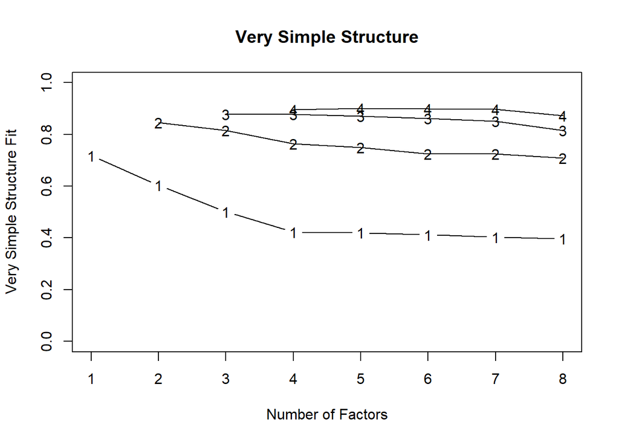

```r
#str(Xs.vss);

Xs.vss.dataframe = cbind(1:maxFactors,Xs.vss$vss.stats[,c(1:3)]);

colnames(Xs.vss.dataframe) = c("Factors","d.f.","chisq","p.value");

Xs.vss.dataframe;
```

[output not shown]

```r
# we have so much data, it is saying we could use many different factors ...

# the choice for "4" seems to mean the "gain of a new factor" is minimal.

# https://personality-project.org/r/vss.html

# `__student_access__\sample_latex_files\Multivariate-2009\MonteShaffer_Stats519_HW5.pdf` # See HW5, pg 11 of a custom `multifactanal` table I constructed to use multiple criteria to assess optimal factors ...
```

### 3.3.2 Scree: Using eigenvalues from Correlation

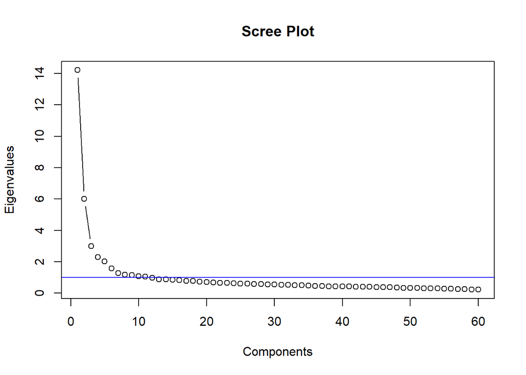

```r
Xs.corr.eigen = eigen(Xs.corr);

library(nFactors);  # install.packages("nFactors", dependencies=TRUE);

# Basic
plotuScree(Xs.corr.eigen$values);
abline(h = 1, col="blue");
```

```r
Xs.corr.eigen$values[Xs.corr.eigen$values > 1];
```

```
##  [1] 14.217853  6.021335  3.009303  2.306947  2.023039  1.587564  1.278967
##  [8]  1.193839  1.146214  1.073433  1.045484
```

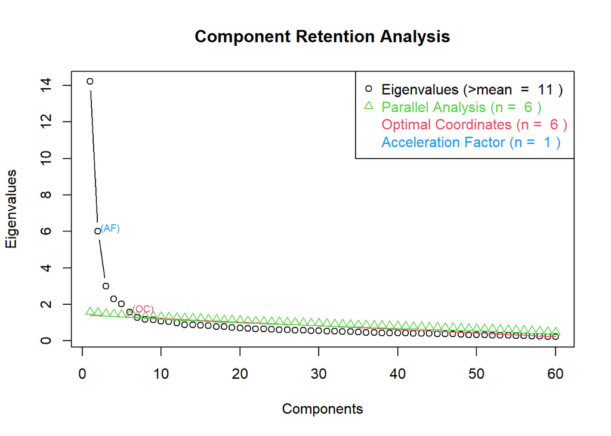

```r
# technically 11 are greater than 1.
# 5-6 would seem reasonable based on what we see


# Steroids
nResults = nScree(eig = Xs.corr.eigen$values,
              aparallel = parallel(
                              subject = nrow(Xs),
                              var = ncol(Xs) )$eigen$qevpea);

plotnScree(nResults, main="Component Retention Analysis");
```

```r
# This is suggesting "6" based on Parallel Analysis and Optimal Coordinates ...
```